# ネットワークプログラミング

> オブジェクト指向プログラミングおよび演習2 第13回

> Webのようなネットワークアプリケーションではなく、低水準のネットワーク・プロトコルを直接使ったアプリケーション開発について学びましょう。

# ネットワークプログラミングの前に

コンピュータ・ネットワークに対する知識をつけましょう。

※ネットワークに関する知識でプログラミングに必要な内容はこの資料でも解説されていることがあります。  
しかし、コンピュータネットワークの基本知識については解説しません。各自で勉強するようにしてください。

## 他の講義のWebアプリケーションもネットワークプログラミングの一種

他の講義で行うようなWebアプリケーションも、ネットワークプログラミングに含まれます。 Webアプリケーションは、ネットワークの通信にHTTPというプロトコル（通信規約）を使用しており、Webクライアント（Webブラウザ）にてURIを指定することがプログラムを実行する手順となります。

Webアプリケーションがあれば、大抵のネットワーク経由で実行するプログラムはできてしまいます。  
しかし、HTTPによる高水準アクセスを用いて実行されるプログラムでは、できることに制限が付きます。

たとえば、独自のプロトコルを持つTCP/IPアプリケーション、バイナリデータを用いた暗号通信（HTTPSを除く）、リアルタイムでのネットワーク対戦ゲームなどでは、独自に構成したルールを用いる必要があります。

Javaでは、そういったネットワーク通信にも対応できるように標準でいくつかのライブラリが提供されています。

## Javaでのネットワーク低水準アクセス

Javaでのネットワーク低水準アクセス（TCP/IPを利用した通信）を利用する場合は、`java.net.*`のライブラリセットを用います。

## OSI参照モデルとTCP/IPで見る高水準アクセスと低水準アクセス

OSI参照モデルは以下のように、ネットワーク通信を役割ごとに7つの階層に分けた、ネットワーク通信の理想型です。 あくまでもモデルなので、今のインターネットを始めとしたコンピュータネットワークがこれに完全準拠しているのではありません。

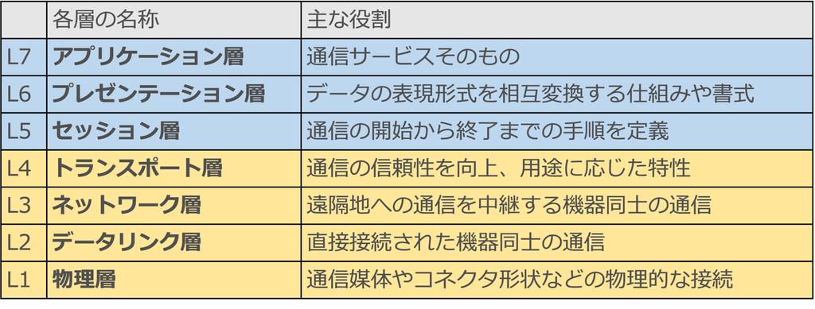

### OSI参照モデルでの通信の理想型

OSI参照モデルの各レイヤは、互いに渡すべきデータ形式が決まっている以外、他のレイヤへの干渉はいっさいしないことが理想とされます。

### レイヤの構造にしていることでのメリット

各層が機能・役割ごとに独立しており、順序さえ守れば他の層を気にする必要はないという点があります。 順序が決まっていることでどこまでOKか判断できるため、問題点の切り出しが容易です。

## TCP/IP

TCP/IPは、OSI参照モデルの各レイヤに対応した、世界標準のプロトコルをまとめたプロトコル・スタックを指します。 名称上、TCPとIPしかないように思われるかもしれませんが、TCP/IPには数多くのプロトコルが含まれます。

OSI参照モデルと照らし合わせると、以下のようになります。

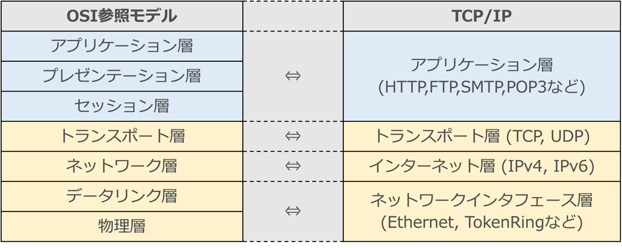

TCP/IPのプロトコルには、OSI参照モデルの複数のレイヤを跨いだプロトコルが存在します。 これらは通信を行うアプリケーションなどの仕様上、敢えてそれぞれのレイヤに分割する必要性がなかったり、分割不可能な場合があるためです。  
こればかりは現時点ではどうすることもできず、OSI参照モデルが理想型と言われ、TCP/IPが現実解と言われる理由として挙げられます。

TCP/IPのプロトコル・スタックでは、アプリケーションレイヤ、トランスポートレイヤ、インターネットレイヤ、ネットワークアクセスレイヤ（リンクレイヤとも呼ばれることがある）の4つのレイヤで分割されます。

たとえば、皆さんが今から作成するプログラムでは、セッションの開始、終了や文字コードなどアプリケーション内で定義する必要があります。  
アプリケーションの作成を、OSI参照モデルに従うならば、レイヤ7、レイヤ6、レイヤ5に相当する機能をプログラム内で実装する必要があります。

## JavaでのTCP/IPネットワークプログラミング

`java.net.*`のライブラリセットは、TCP/IPのネットワーク通信の基礎的なレイヤである、トランスポートレイヤ、インターネットレイヤ、ネットワークアクセスレイヤで必要な作業をすべて担います。

この通信を担うレイヤ役割は、どのアプリケーションでも違いがなく、Javaのライブラリ、OS、ハードウェアが担当してくれます。

アプリケーション開発者は、

1. どの相手と通信を行うか、と言うホスト名およびIPアドレス
   - ホスト名やURLに使用されるドメインは、他のプロトコルを使用して最終的にIPアドレスに変換されています。
2. どのアプリケーションと通信を行うか、アプリケーションの識別番号であるポート番号
   - ポート番号は、トランスポートレイヤにて使用されています。

の2つを用意してあげれば良いのです。

また、ネットワークのプログラムでは基本的に一対多の通信が行われます。 そのため **マルチスレッドプログラミング** が必須事項となります。シングルスレッドで入力待ち受けを行ってしまうと、そのスレッドが処理中であった場合は他のホストからの通信を待ち受けることができなくなってしまいます。

非常にざっくりとしたネットワークプログラミングの解説になりましたが、今から、課題のサンプルソースを読みながら、Javaでのネットワークプログラミングを学んでいきましょう。

## ざっくりソケット通信とは

Javaに限らず、TCP/IPアプリケーションを構築する場合は、ソケット通信と呼ばれる通信プログラムを作成します。

ソケットとは、TCP/IPアプリケーション間でデータのやり取りを行うための出入り口のことをいいます。

OSI参照モデルでのセッション層に当たるレイヤで動作し、アプリケーションからは、IPアドレスとポート番号を指定することで通信の確立までを行います。 ソケット通信は、TCP/IPアプリケーションの中核とよんでも差し支えないほど重要な機能で、アプリケーションのプロトコル設計は、ソケット通信の上に作成するようなイメージとなります。

Javaにおけるソケット通信には、`java.net.ServerSocket`でサーバー側での待受を行い、`java.net.Socket`がクライアント側とサーバー側を繋ぐ役割を担います。

標準APIのドキュメントは以下のリンク先を参照してください。

- [ServerSocket (Java SE 17 & JDK 17 )](https://docs.oracle.com/javase/jp/17/docs/api/java.base/java/net/ServerSocket.html)
- [Socket (Java SE 17 & JDK 17 )](https://docs.oracle.com/javase/jp/17/docs/api/java.base/java/net/Socket.html)

# ソケット通信サンプル

## クライアント側のプログラム

Moodleにアップロードされている`TCPMessageClient.zip`にて、TCP/IPクライアントアプリケーションのソースコードがあります。 各自でプロジェクトを作り、ソースコードをコピーするなどして開いてください。

クライアントプログラムと、サーバープログラムを別々に作成し、サーバーを起動後にクライアントプログラムを起動することで接続できるかの確認を行ってください。

## 文字列を受け取り、受け取った文字列をオウム返しするサーバープログラムの作成

新規にプロジェクトを作成し、以下のコードを貼り付けます。

```java
import java.io.BufferedReader;
import java.io.InputStreamReader;
import java.io.OutputStreamWriter;
import java.io.PrintWriter;
import java.net.ServerSocket;
import java.net.Socket;

public class EchoServer {

  public static void main(String[] args) throws Exception {
    try (
            ServerSocket ss = new ServerSocket(12345);  // サーバー立ち上げ port:12345
            Socket socket = ss.accept(); // クライアントからの接続待ち受け
    ) {
      try (
              BufferedReader in = new BufferedReader(new InputStreamReader(socket.getInputStream()));
              PrintWriter out = new PrintWriter(new OutputStreamWriter(socket.getOutputStream()), true);
              ) {
        // 通信処理自体を無限ループ化
        while (true) {
          // クライアントからのデータ受信 待ち受け
          String message = in.readLine();
          // 「exit」メッセージを受け取ったら無限ループから抜ける
          if (message.equals("exit")) {
            break;
          }
          // メッセージをそのままクライアントに送信
          out.println(message);
        }
      }
    }
  }
}
```

サーバープログラム側を実行すると、自分のPCのTCPポート`12345`にサーバーアプリケーションが待受状態になります。(実行後の出力内容はありません。)

TCPMessageClientプロジェクトのメインメソッド内を確認し、接続ポートが`12345`、接続先ホストが`localhost`になっていることを確認して実行してみましょう。

実行後、サーバーに接続されたら、適当なテキストを入力し、returnキーを送信してみましょう。 以下の実行サンプルでは、「aaa」「bbb」「ccc」「日本語も使えます」「exit」を送信しています。

```bash
サーバーに接続しました: localhost/127.0.0.1:12345
aaa
aaa
bbb
bbb
ccc
ccc
日本語も使えます
日本語も使えます
exit
サーバーから切断されました: localhost/127.0.0.1:12345
```

このEchoServerは、サーバー側にマルチスレッドは実装されていません。そのため、複数のクライアントを接続することはできません。

少し改変して、人工無脳サーバーを作成してみましょう。

# マルチスレッドで待受する人工無脳サーバーの作成

`SuperAI`プロジェクトを作成します。

## `Processor.java`クラスの作成

内容は以下のコードを使ってください。

```java
import java.io.BufferedReader;
import java.io.InputStreamReader;
import java.io.OutputStreamWriter;
import java.io.PrintWriter;
import java.net.Socket;

class Processor extends Thread {

  java.net.Socket socket;

  public Processor(Socket s) {
    socket = s;
  }

  @Override
  public void run() {
    try (
            BufferedReader in = new BufferedReader(new InputStreamReader(socket.getInputStream()));
            PrintWriter out = new PrintWriter(new OutputStreamWriter(socket.getOutputStream()), true);) {

      out.println("ようこそ！");

      // 通信処理自体を無限ループ化
      while (true) {

        // クライアントからのデータ受信 待ち受け
        String message = in.readLine();

        // 「exit」メッセージを受け取ったら無限ループから抜ける
        if (message.equals("exit")) {
          break;
        }

        if (message.startsWith("こんにちは")) {
          out.println("こんにちは！今日はあいにくの天気ですね……。");
        } else if (message.startsWith("こんばんは")) {
          out.println("今はお昼ですよ？？こんにちは！");
        } else if (message.endsWith("?") || message.endsWith("？")) {
          out.println("その質問にはお答えしかねます。");
        } else if (message.contains("天気")) {
          out.println("今日はいい天気ですよ！");
        } else {
          out.println("おっしゃっている言葉が理解できません……");
        }
      }

      // ソケットを閉じる
      socket.close();

    } catch (Exception e) {
      throw new RuntimeException(e);
    }
  }
}
```

## `SuperAI.java`のメインメソッドの作成

```java
import java.net.ServerSocket;
import java.net.Socket;

public class SuperAI {

  public static void main(String[] args) throws Exception {

    try (ServerSocket ss = new ServerSocket(12345)) {
      while (true) {
        Socket s = ss.accept();
        System.out.printf("クライアントからの接続: %s:%d\n", s.getInetAddress(), s.getPort());
        Processor app = new Processor(s);
        app.start();
      }
    }
  }
}
```

## 実行確認してみましょう

```bash
サーバーに接続しました: localhost/127.0.0.1:12345
ようこそ！
こんにちは
こんにちは！今日はあいにくの天気ですね……。
あああ
おっしゃっている言葉が理解できません……
名前はなんですか？
その質問にはお答えしかねます。
exit
サーバーから切断されました: localhost/127.0.0.1:12345
```

マルチスレッド化されているので、友人のPCが同一ネットワーク内に所属しているならIPアドレスがわかれば友人のPCのサーバーアプリケーションと会話することも可能です。

自分のPCのIPアドレスを調べるには、以下のコマンドが使えます。

```bash
$ ifconfig
```

ネットワークに接続しているインターフェイスを確認して、そのインターフェイスに設定されているinetアドレスが自分のPCのIPアドレスです。  
それを友人に伝えて接続してみると良いでしょう。

`ifconfig`では、たくさん情報が出てきて困る場合は、`grep inet`という検索コマンドにパイプ処理をしてあげましょう。

```bash
$ ifconfig | grep inet
```

# TCPクライアントとしてのtelnet,ncコマンド

## テキストデータをネットワーク経由で送受信するプログラム

昔より、ネットワーク上でのリモートアクセスなどで使われるプログラムに、`telnet`と呼ばれるものがあります。

Macの場合、残念ながらHigh Sierra以降削除されています。  
Sierra以前でも、文字コード関連の重大なバグが含まれており完璧な動作は保証されません。

今回の講義では、TCPMessageClientのプログラムにてその機能を代替させていますが、telnetに代替する`nc`コマンドが用意されています。

### telnetの代わりにnc(netcat)を使うには

```bash
$ telnet localhost 12345
```

上記のコマンドは、以下のコマンドに置き換えられます。

```bash
$ nc localhost 12345
```

上記で接続できない場合、`-t`オプションで、nc(netcat)コマンドをtelnet互換で動作させることができます。

ncコマンドのマニュアルは、`$ man nc`で確認できます。